# Visualizing Data with R: From Basics to Publication-Ready Graphics–Part 2

Nevada Bioinformatics Center

2025-05-12

## 1. Introduction

### 1.1 Recap

In the previous session, we delved into the versatility of the R package ggplot2. ggplot2 makes visualizations in data layers, aesthetics (aes), and geometries (geoms).

We explored three core components:

1. **Data**: The dataset you’re visualizing.
2. **Aesthetics (aes)**: How data variables are visually represented, such as position, color, and size.
3. **Geometries (geoms)**: The plot types or elements, like points, lines, or bars, used to display data.

We practiced creating simple scatter plots and enhanced them by differentiating data points, such as by cylinder count in the `mtcars` dataset, using aesthetic mappings. We also learned to layer these elements to add complexity, including adding regression lines to show trends. We covered customization techniques in ggplot2, adjusting visual elements like line types and point sizes.

In this session, we will build on these skills, introducing more advanced data manipulation and visualization strategies to further enhance our data narratives with ggplot2.

### 1.2 Overview

In this session, we will learn about plotting summary and raw data as well as delve deeper into plot customization.

Before we make our figures, let’s review our working dataset about cars.

```r
# View the built-in dataset
head(mtcars)
```

```
##                    mpg cyl disp  hp drat    wt  qsec vs am gear carb
## Mazda RX4         21.0   6  160 110 3.90 2.620 16.46  0  1    4    4
## Mazda RX4 Wag     21.0   6  160 110 3.90 2.875 17.02  0  1    4    4
## Datsun 710        22.8   4  108  93 3.85 2.320 18.61  1  1    4    1
## Hornet 4 Drive    21.4   6  258 110 3.08 3.215 19.44  1  0    3    1
## Hornet Sportabout 18.7   8  360 175 3.15 3.440 17.02  0  0    3    2
## Valiant           18.1   6  225 105 2.76 3.460 20.22  1  0    3    1
```

The mtcars dataset contains data on 32 car models, with the following columns:

- **mpg:** Miles per gallon (fuel efficiency).
- **cyl:** Number of cylinders in the engine (4, 6, or 8).
- **disp:** Engine displacement (in cubic inches).
- **hp:** Gross horsepower.
- **drat:** Rear axle ratio.
- **wt:** Weight of the car (in 1000s of pounds).
- **qsec:** 1/4 mile time (time in seconds to cover a quarter mile).
- **vs:** Engine shape (0 = V-shaped, 1 = straight).
- **am:** Transmission type (0 = automatic, 1 = manual).
- **gear:** Number of forward gears.
- **carb:** Number of carburetors.

In the dataset, we have categorical data (`cyl`, `vs`, `am`, `gear`, `carb`) and continuous data (`mpg`, `disp`, `hp`, `drat`, `wt`, `qsec`).

## 2. Data Summarization

### 2.1 Reviewing the Data

Before we delve into making figures, we need to understand our data by exploring its distribution. Visualizing different variables in our dataset not only helps us identify patterns and trends but also highlights how the distribution of values can influence the statistical methods we use and the insights we draw.

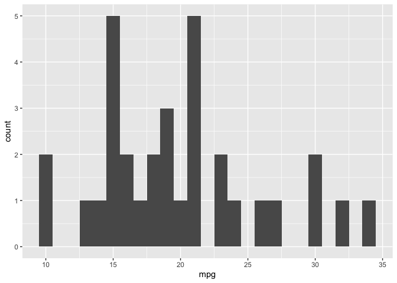

```r
# Load libraries and data
library(ggplot2)
data("mtcars")

ggplot(mtcars, aes(x=mpg)) + geom_histogram(binwidth=1)
```

The `binwidth` in `geom_histogram()` determines the width of each bin, which groups the data into intervals along the x-axis to create the histogram; smaller binwidths result in more detailed distributions, while larger binwidths provide a broader summary.

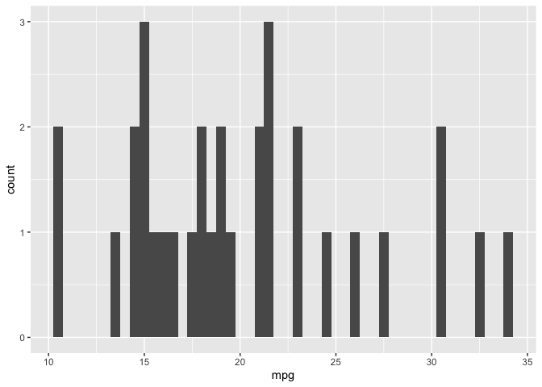

```r
ggplot(mtcars, aes(x=mpg)) + geom_histogram(binwidth=0.5)
```

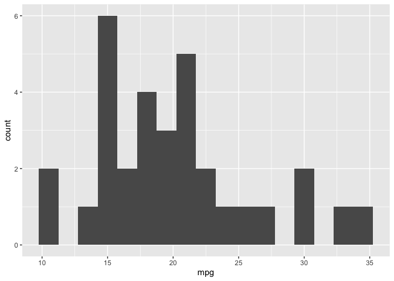

```r
ggplot(mtcars, aes(x=mpg)) + geom_histogram(binwidth=1.5)
```

Too large of bins may obscure the data.

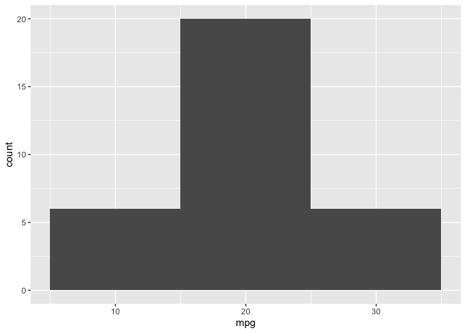

```r
ggplot(mtcars, aes(x=mpg)) + geom_histogram(binwidth=10)
```

Let’s look at our next variable of interest: `cyl`. If you run the following code you will get an error.

```r
ggplot(mtcars, aes(x=factor(cyl))) + geom_histogram(binwidth = 1)
```

The error occurs because `geom_histogram()` expects a continuous variable on the x aesthetic to calculate bins, while `factor` creates a discrete variable. In this case, we could remove `factor` since our variable is numeric.

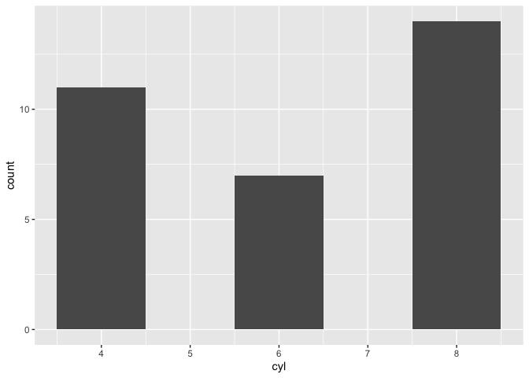

```r
ggplot(mtcars, aes(x=cyl)) + geom_histogram(binwidth = 1)
```

However, `geom_bar()` is used for categorical variables.

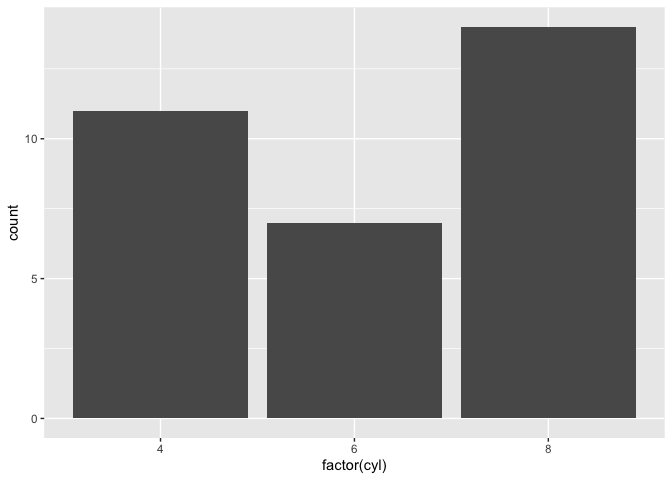

```r
ggplot(mtcars, aes(x = factor(cyl))) +   # Factor again for categorical
  geom_bar()
```

### 2.2 Plotting Summary Statistics with dplyr

We can efficiently summarize our data for visualization using the `dplyr` package. This allows us to plot means and standard errors.

First, install and load the necessary libraries:

```r
# Install libraries if necessary
if (!requireNamespace("dplyr", quietly = TRUE)) {
  install.packages("dplyr")
}

if (!requireNamespace("tidyverse", quietly = TRUE)) {
  install.packages("tidyverse")
}

# Load libraries
library(dplyr)
library(tidyverse)                                 # data manipulation
```

Now let’s aggregate and summarize the `mtcars` dataset by the number of cylinders (`cyl`). We will calculate mean and standard deviation for miles per gallon (`mpg`) and quarter-mile time (`qsec`), and then derive standard errors and confidence intervals:

```r
mtcars_summary <- mtcars %>%
  group_by(cyl) %>%  # Group by the number of cylinders
  summarise(
    mpg_mean = mean(mpg, na.rm = TRUE),  # mpg mean
    mpg_sd = sd(mpg, na.rm = TRUE),      # mpg standard deviation
    mpg_n = n(),                         # mpg count
    qsec_mean = mean(qsec, na.rm = TRUE),  # qsec mean
    qsec_sd = sd(qsec, na.rm = TRUE),      # qsec standard deviation
    qsec_n = n()                           # qsec count
  ) %>%
  mutate(
    mpg_se = mpg_sd / sqrt(mpg_n),  # mpg standard error
    mpg_lower_ci = mpg_mean - qt(1 - (0.05 / 2), mpg_n - 1) * mpg_se,  # mpg lower 95% CI
    mpg_upper_ci = mpg_mean + qt(1 - (0.05 / 2), mpg_n - 1) * mpg_se,  # mpg upper 95% CI
    qsec_se = qsec_sd / sqrt(qsec_n),  # qsec standard error
    qsec_lower_ci = qsec_mean - qt(1 - (0.05 / 2), qsec_n - 1) * qsec_se,  # qsec lower 95% CI
    qsec_upper_ci = qsec_mean + qt(1 - (0.05 / 2), qsec_n - 1) * qsec_se   # qsec upper 95% CI
  )
```

Let’s look at a bar graph comparing the average quarter mile times (`qsec_mean`) across different numbers of cylinders (`cyl`).

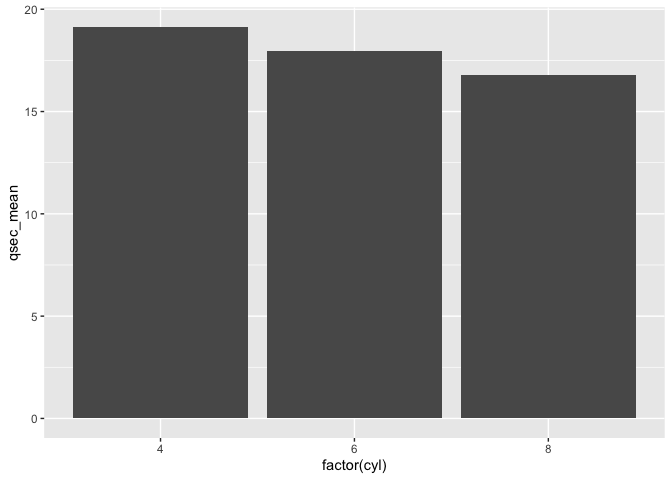

```r
ggplot(data = mtcars_summary, aes(x = factor(cyl), y = qsec_mean)) +
  geom_bar(stat = "identity")
```

Now, let’s color the bars by the number of cylinders.

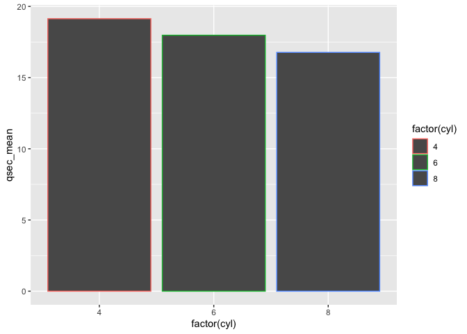

```r
ggplot(data = mtcars_summary, aes(x = factor(cyl), y = qsec_mean, color = factor(cyl))) +
  geom_bar(stat = "identity")
```

#### Wait, why didn’t that work?

In `geom_bar` (and many other geoms), the `color` attribute defines the outline of the bars, not their fill. To color the bars themselves, we need to specify the `fill` attribute.

**Tip:** Confusion between `color` and `fill` is common. Remember, `color` affects outlines or entire objects, while `fill` impacts the inside of geometric shapes. This distinction is important when setting attributes in `aes` or directly in the geoms.

$~$

Let’s try again with `fill`:

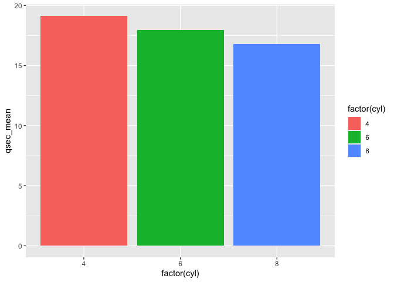

```r
ggplot(data = mtcars_summary, aes(x = factor(cyl), y = qsec_mean, fill = factor(cyl))) +
  geom_bar(stat = "identity")
```

How do we use `color` appropriately in our `geom_bar()`?

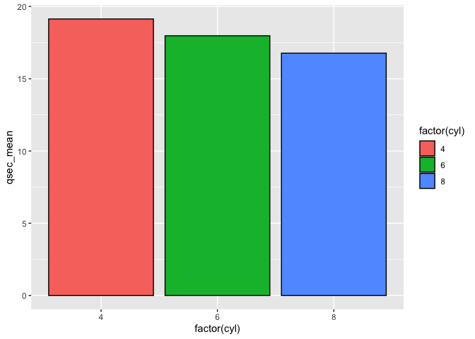

```r
ggplot(data = mtcars_summary, aes(x = factor(cyl), y = qsec_mean, fill = factor(cyl))) +
  geom_bar(stat = "identity", color = "black") # Color is the outline
```

Since we are visualizing the mean, let’s add error bars. Error bars can be added manually or using the `Hmisc` package, which provides additional statistical functions.

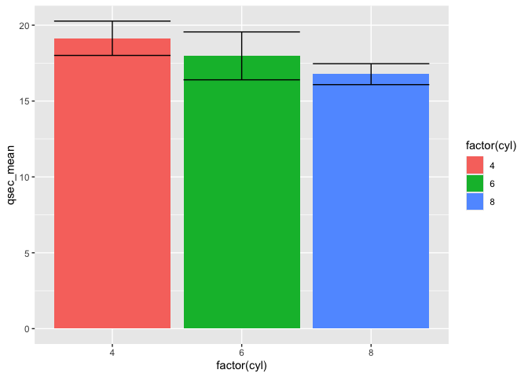

```r
# Manually adding error bars
ggplot(data = mtcars_summary, aes(x = factor(cyl), y = qsec_mean, fill = factor(cyl))) +
  geom_bar(stat = "identity") +
  geom_errorbar(aes(ymin = qsec_lower_ci, ymax = qsec_upper_ci))
```

### 2.3 Plotting Summary Statistics with Hmisc

The `Hmisc` package can automate the calculation of summary statistics and their visualization. It is especially useful for more complex statistical summaries that go beyond the basics provided by ggplot2.

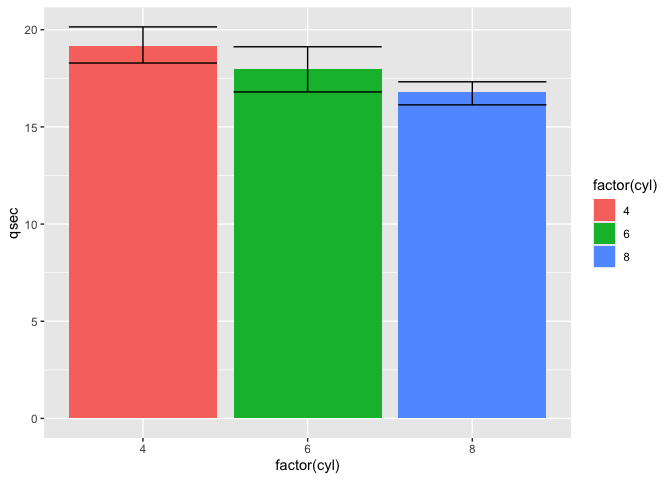

```r
# Install and load the Hmisc package
if (!requireNamespace("Hmisc", quietly = TRUE)) {
  install.packages("Hmisc")
}
library(Hmisc)

# Use the regular dataset and not the summary we made
ggplot(data = mtcars, aes(x = factor(cyl), y = qsec, fill = factor(cyl))) +
  stat_summary(fun = mean, geom = "bar") +
  stat_summary(fun.data = mean_cl_boot, geom = "errorbar") # Add error bars showing confidence intervals
```

Let’s switch to using points for the means along with error bars for a closer view.

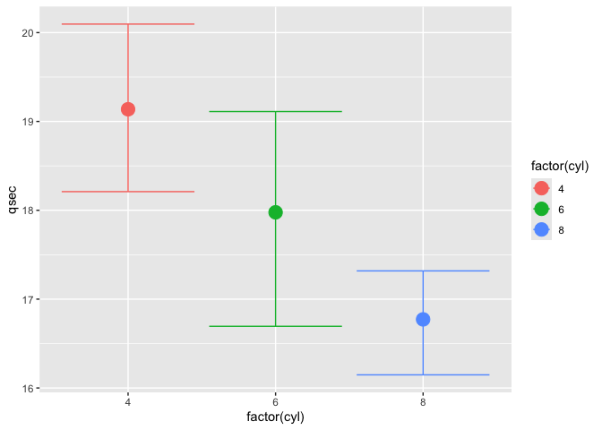

```r
ggplot(data = mtcars, aes(x = factor(cyl), y = qsec, color = factor(cyl))) +
  stat_summary(fun = mean, geom = "point", size = 5) +
  stat_summary(fun.data = mean_cl_boot, geom = "errorbar")
```

$~$

We are now using the `color` attribute to modify our points because, the `color` attribute changes the entire appearance of standard points, which don’t have a separate fillable area. The `fill` attribute is only applicable to points that have both fillable interiors and outlines. Let’s make further adjustments, noting that we can modify specific parts of the figure by tweaking individual `geom` elements.

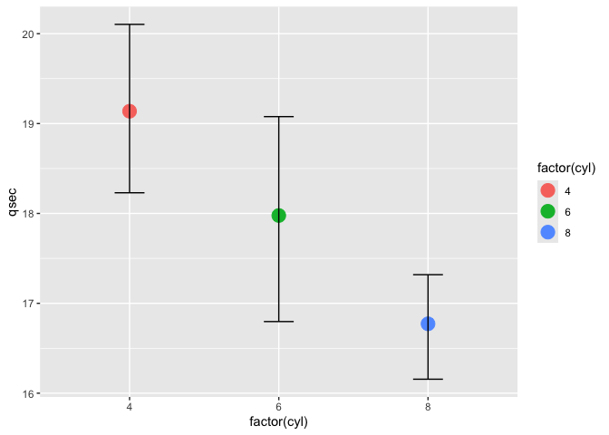

```r
ggplot(data = mtcars, aes(x = factor(cyl), y = qsec, color = factor(cyl))) +
  stat_summary(fun = mean, geom = "point", size = 5) +
  stat_summary(fun.data = mean_cl_boot, geom = "errorbar",
    color = "black", width = 0.2)
```

**Note:** Did you notice the slight change in the figure legend? If your legend doesn’t seem appropriate check the location and features being pulled from your `aes`.

$~$

Let’s also adjust our layers:

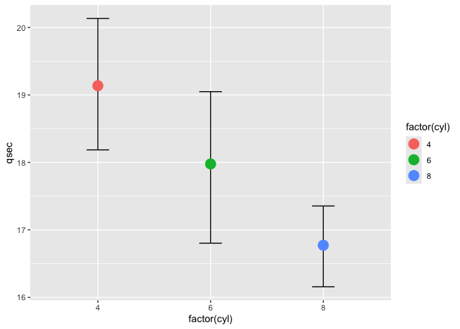

```r
ggplot(data = mtcars, aes(x = factor(cyl), y = qsec, color = factor(cyl))) +
  stat_summary(fun.data = mean_cl_boot, geom = "errorbar",
    color = "black", width = 0.2) +
  stat_summary(fun = mean, geom = "point", size = 5)
```

By reordering we have layered the error bars behind the points.

### 2.4 Why Bar Plots are Bad

**Question:** Are the two datasets alike?

Let’s collect our data:

```r
set.seed(123)  # For reproducibility

# Red data
red_data <- rnorm(1000, mean = 100, sd = 15)

# Blue data (using exponential distribution scaled to match mean and SD of normal)
blue_data <- rexp(1000, rate = 0.1)
desired_mean <- mean(red_data)
desired_sd <- sd(red_data)
blue_data <- (blue_data - mean(blue_data)) / sd(blue_data) * desired_sd + desired_mean

# Combine into a data frame
data <- data.frame(
  group = rep(c("Red", "Blue"), each = length(red_data)),
  value = c(red_data, blue_data)
)

data$group <- factor(data$group, levels = c("Red", "Blue"))

# View our data

head(data)
```

```
##   group     value
## 1   Red  91.59287
## 2   Red  96.54734
## 3   Red 123.38062
## 4   Red 101.05763
## 5   Red 101.93932
## 6   Red 125.72597
```

Let’s look at the distributions:

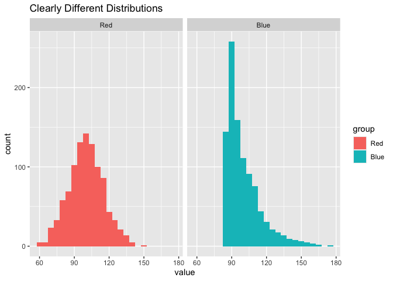

```r
ggplot(data, aes(x = value, fill = group)) +
  geom_histogram(binwidth = 5) +
  facet_wrap(~ group) +
  labs(title = "Clearly Different Distributions")
```

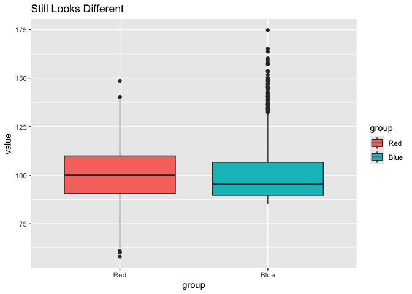

```r
ggplot(data, aes(x = group, y = value, fill = group)) +
  geom_boxplot() +
  labs(title = "Still Looks Different")
```

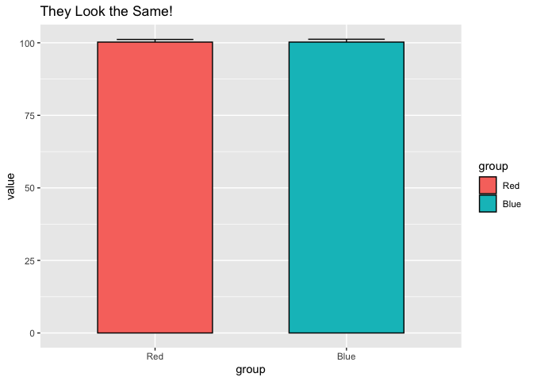

```r
ggplot(data, aes(x = group, y = value, fill = group)) +
  stat_summary(fun.data = mean_cl_boot, geom = "errorbar", width = 0.4) +
  stat_summary(fun = mean, geom = "bar", color = "black", width = 0.6) +
  labs(title = "They Look the Same!")
```

#### Friends Don’t Let Friends Make Barplots

## 3. Plotting Raw Data

As we just saw, relying solely on summary statistics like means or medians can sometimes obscure the underlying distribution and variability present in your dataset. Displaying raw data alongside summary statistics offers a more comprehensive view, revealing outliers, data distribution patterns, and potential anomalies that summary measures alone might miss. This approach enhances transparency and provides a fuller understanding of the data’s behavior. In this section, we’ll explore various methods to effectively incorporate raw data into our visualizations.

Let’s create a few standard plots that incorporate the full dataset:

$~$

#### Boxplot

Boxplots are statistical visualizations that succinctly represent the distribution of data through quartiles and outliers. They highlight the median, range, and variability within a dataset, making it easy to compare distributions across different groups or variables.

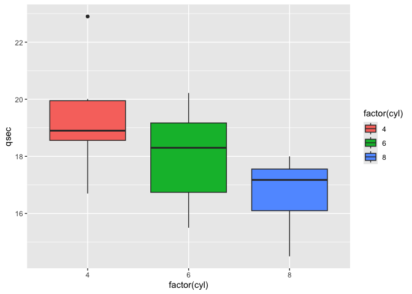

```r
ggplot(data = mtcars, aes(x = factor(cyl), y = qsec, fill = factor(cyl))) +
  geom_boxplot()
```

$~$

#### Violin Plot

Violin plots are similar to boxplots but provide a deeper insight into the distribution of data, showing the probability density of the data at different values. These plots are particularly useful for revealing multiple modes or peaks in the data, displaying both the spread and the density of the data points.

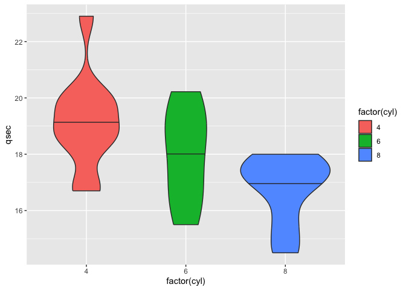

```r
ggplot(data = mtcars, aes(x = factor(cyl), y = qsec, fill = factor(cyl))) +
  geom_violin(draw_quantiles = 0.5)
```

$~$

#### Raw Data Points

Plotting raw data as points is a straightforward method to visually assess the distribution, trends, and potential anomalies within a dataset. This allows for a direct observation of each data point, helping to identify patterns, outliers, and the overall spread of data across different categories or variables.

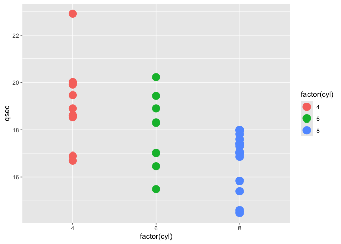

```r
ggplot(data = mtcars, aes(x = factor(cyl), y = qsec, color = factor(cyl))) + # Switch back to color
  geom_point(size = 5)
```

$~$

#### Plotting Raw Data and Summary Stats

Plotting raw data points alongside summary statistics like the mean and error bars provides a comprehensive view of the data. Let’s plot our raw data points with the mean and error bars overlayed:

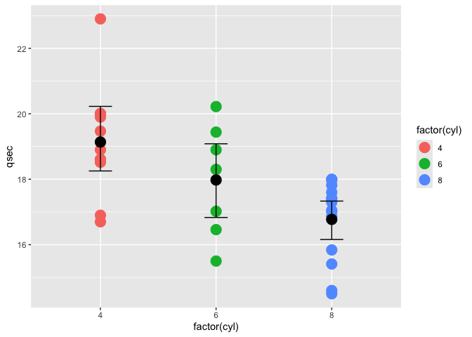

```r
ggplot(data = mtcars, aes(x = factor(cyl), y = qsec, color = factor(cyl))) +
  geom_point(size = 5) +
  stat_summary(fun.data = mean_cl_boot, geom = "errorbar",
        color = "black", width = 0.2) +
  stat_summary(fun = mean, geom = "point",
    size = 5, color = "black")
```

### Now we have a(n ugly) figure!

## 4. Customizing Figures

### 4.1 Themes

The default grey background in `ggplot2` figures can often distract from the data being presented. Fortunately, `ggplot2` offers a variety of themes that can enhance the visual appeal and clarity of your figures. For example, `theme_classic()` provides a clean, traditional look with no background grid and a white plot area, making it suitable for publication. You can apply this theme easily by appending it to your ggplot chain to instantly improve the aesthetics of your plot.

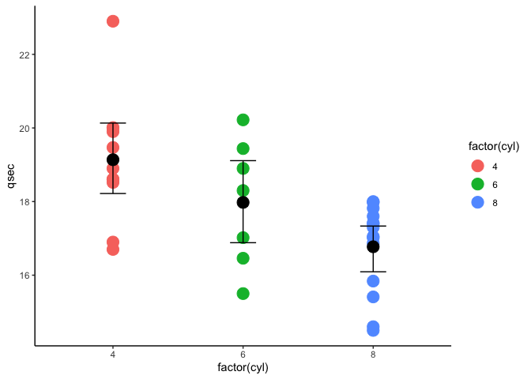

```r
ggplot(data = mtcars, aes(x = factor(cyl), y = qsec, color = factor(cyl))) +
  geom_point(size = 5) +
  stat_summary(fun.data = mean_cl_boot, geom = "errorbar",
        color = "black", width = 0.2) +
  stat_summary(fun = mean, geom = "point",
    size = 5, color = "black") +
  theme_classic()
```

Much better! Try out `theme_minimal()` and `theme_bw()`.

```r
ggplot(data = mtcars, aes(x = factor(cyl), y = qsec, color = factor(cyl))) +
  geom_point(size = 5) +
  stat_summary(fun.data = mean_cl_boot, geom = "errorbar",
        color = "black", width = 0.2) +
  stat_summary(fun = mean, geom = "point",
    size = 5, color = "black") +                 # Add your theme here
```

Additionally, we can set a global theme that ggplot will use for every figure.

```r
# Set our theme to classic
theme_set(theme_classic())
```

Now the rest of our figures will have this theme.

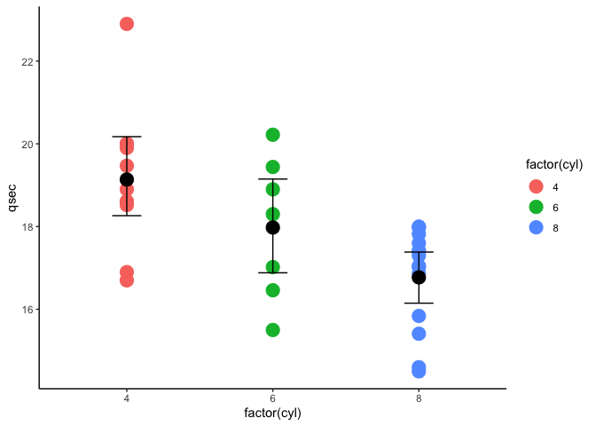

```r
ggplot(data = mtcars, aes(x = factor(cyl), y = qsec, color = factor(cyl))) +
  geom_point(size = 5) +
  stat_summary(fun.data = mean_cl_boot, geom = "errorbar",
        color = "black", width = 0.2) +
  stat_summary(fun = mean, geom = "point",
    size = 5, color = "black")
```

### 4.2 Shapes and Colors

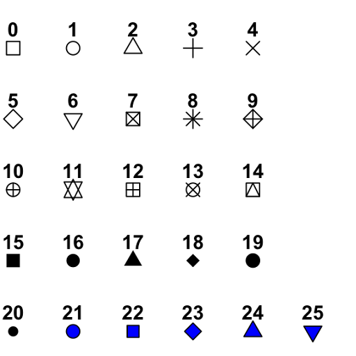

Let’s use 21 for our points.

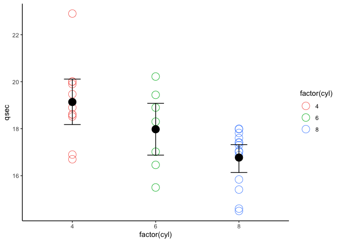

```r
ggplot(data = mtcars, aes(x = factor(cyl), y = qsec, color = factor(cyl))) +
  geom_point(size = 5, pch = 21) +
  stat_summary(fun.data = mean_cl_boot, geom = "errorbar",
        color = "black", width = 0.2) +
  stat_summary(fun = mean, geom = "point",
    size = 5, color = "black")
```

Since we’ve specified `color`, it affects the outline of the points. We’ll adjust `geom_point()` to set the outline color to black, and use `aes` to assign `fill` to color the interior of the points based on `cyl`.

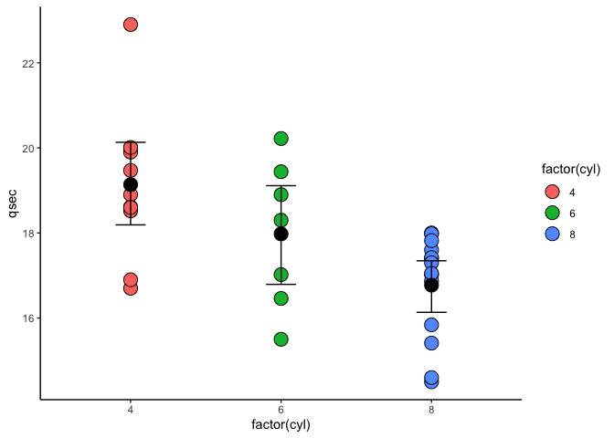

```r
ggplot(data = mtcars, aes(x = factor(cyl), y = qsec)) +
  geom_point(size = 5, pch = 21, color = "black", aes(fill = factor(cyl))) +
  stat_summary(fun.data = mean_cl_boot, geom = "errorbar",
        color = "black", width = 0.2) +
  stat_summary(fun = mean, geom = "point",
    size = 5, color = "black")
```

$~$

Notice how we set the `color` attribute to define the outline of the points. By specifying this inside the `geom_point()`, we can freely choose any outline color.

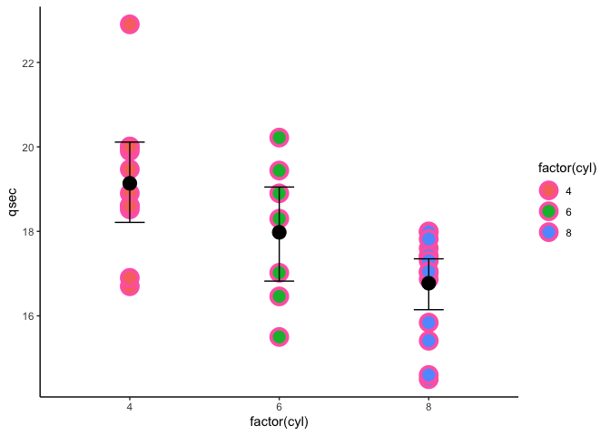

```r
ggplot(data = mtcars, aes(x = factor(cyl), y = qsec)) +
  geom_point(size = 5, pch = 21, color = "hotpink", stroke = 2, # Thicken border
             aes(fill = factor(cyl))) +
  stat_summary(fun.data = mean_cl_boot, geom = "errorbar",
        color = "black", width = 0.2) +
  stat_summary(fun = mean, geom = "point",
    size = 5, color = "black")
```

$~$

Unfortunately, the default colors in ggplot2 can be quite unappealing for polished visualizations. Thankfully, there are many ways to customize colors. You can use named colors like blue, green, darkred, and hundreds of others, or you can specify any color using hexadecimal codes (e.g., #FF5733 for a vibrant orange). ggplot2 also supports predefined palettes from the `RColorBrewer` package or continuous scales like `scale_color_gradient()`. If you need more creative options, packages like `viridis` and `wesanderson` provide aesthetically pleasing palettes that ensure readability, even for those with color blindness. It is also a good idea to pick colors associated with your data. For example, yellow and oranges when working with light or blues and greens when working with water. Let’s pick some common car colors:

- **Electric Blue:** #0074D9
- **Lime Green:** #01FF70
- **Ferrari Red:** #FF4136

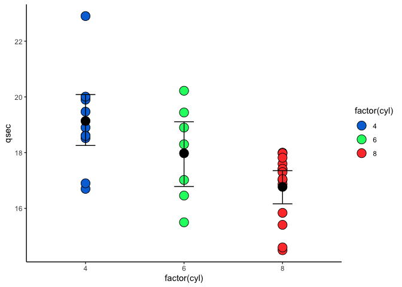

```r
ggplot(data = mtcars, aes(x = factor(cyl), y = qsec)) +
  geom_point(size = 5, pch = 21, color = "black", aes(fill = factor(cyl))) +
  stat_summary(fun.data = mean_cl_boot, geom = "errorbar",
        color = "black", width = 0.2) +
  stat_summary(fun = mean, geom = "point",
    size = 5, color = "black") +
  scale_fill_manual(values = c("#0074D9", "#01FF70", "#FF4136"))
```

**Tip:** In this example, colors are defined in order. However, if you are making lots of plots with multiple layers it is more useful to specify colors by the value’s name, in this case, the number of cylinders: `scale_fill_manual(values = c("4" = "#FF0000", "6" = "#00FF00", "8" = "#0000FF"))`.